# Best Five Starting Players for Chicago Bulls

2019-20 NBA Season

[figure not shown]

Chicago Bulls

## Overall

- In the most recent NBA *season (2018-19)*, Chicago Bulls placed *27th out of 30* (for win-loss record).
- The budget for player contracts next season is *$118 million*.
- The team’s expected ranking in the *2019-20 NBA Season* is *ranked 26th out of 30* .

## Aims of This Project

- Helping Chicago Bulls find the best five starting players for *Each Position* (Point Guard, Shooting Guard, Small Forward, Power Forward and Center).
- Make sure the money will not be use up on just these five players.
- These 5 players should have the ability to help the team achieve the desired goal *Ranked 26 out of 30*

## Data Source

1. 2018-19_nba_player_statistics.csv: sourced from [basketball-reference.com](https://www.basketball-reference.com/leagues/NBA_2019_totals.html)
2. 2018-19_nba_player-salaries.csv: sourced from [hoopshype.com/salaries](https://hoopshype.com/salaries/)
3. 2019-20_nba_team-payroll.csv: sourced from [hoopshype.com/salaries](https://hoopshype.com/salaries/)
4. 2018-19_nba_team-statistics_1.csv: sourced from [basketball-reference.com](https://www.basketball-reference.com/leagues/NBA_2019.html)
5. 2018-19_nba_team-statistics_2.csv: sourced from [basketball-reference.com](https://www.basketball-reference.com/leagues/NBA_2019.html)

## Method

In this data analysis, firstly the data is read, tidied and transformed by *R Studio*. The processed data is then classified as the team data and the individual player data.

Secondly, by the exploratory data analysis, the connections and relations of the data are found.

Thirdly, the model is built regarding the found linear relationships, in order to perform data regressions and to find suitable players.

By exploratory data analysis, the important factors (variables) which influence the game outcomes are found. After analyzing, **Turnovers Per Game, Total Rebounds Per Game, Assists Per Game, Steals Per Game, Blocks Per Game, Points Per Game** have linear relationships with **the number of Wins**.

As a result, a multiple regression model is built, by choosing wins as a response variable, and choosing the above 6 terms as exploratory variables. The model is used for adjusted players’ data, and an regression is performed.

Since the players’ data is individual data, while the team data is the overall playing players’ data of each games, the 6 exploratory varibles are multiplied by 10 in the players’ data as an adjustment. By performing a regression for the adjusted data, the “players’ expected wins” obtained is compared with the “teams’ expected wins”, in order to find a reasonable ratio $ExpW _t/ExpW_p$, then to adjust the players’ expected wins index.

The *adjusted expected wins index* and *players’ salary* are combined to find the most suitable player for Chicago Bulls.

## Model Testing (Expected Wins vs Wins)

| term | estimate | std.error | statistic | p.value | conf.low | conf.high |
| --- | --- | --- | --- | --- | --- | --- |
| (Intercept) | -130.2576287 | 48.5916304 | -2.6806598 | 0.0133515 | -230.7770747 | -29.738183 |
| PTS_Per_G | 1.0381306 | 0.5207504 | 1.9935279 | 0.0581947 | -0.0391238 | 2.115385 |
| STL_Per_G | 1.2069411 | 2.2058918 | 0.5471443 | 0.5895497 | -3.3562936 | 5.770176 |
| AST_Per_G | 0.8431755 | 0.9641787 | 0.8745012 | 0.3908858 | -1.1513801 | 2.837731 |
| TRB_Per_G | 1.7553594 | 1.0175316 | 1.7251154 | 0.0979208 | -0.3495651 | 3.860284 |
| BLK_Per_G | 2.6179474 | 2.6746099 | 0.9788147 | 0.3378557 | -2.9149047 | 8.150799 |
| TOV_Per_G | -4.7138135 | 1.5309530 | -3.0790059 | 0.0053048 | -7.8808311 | -1.546796 |

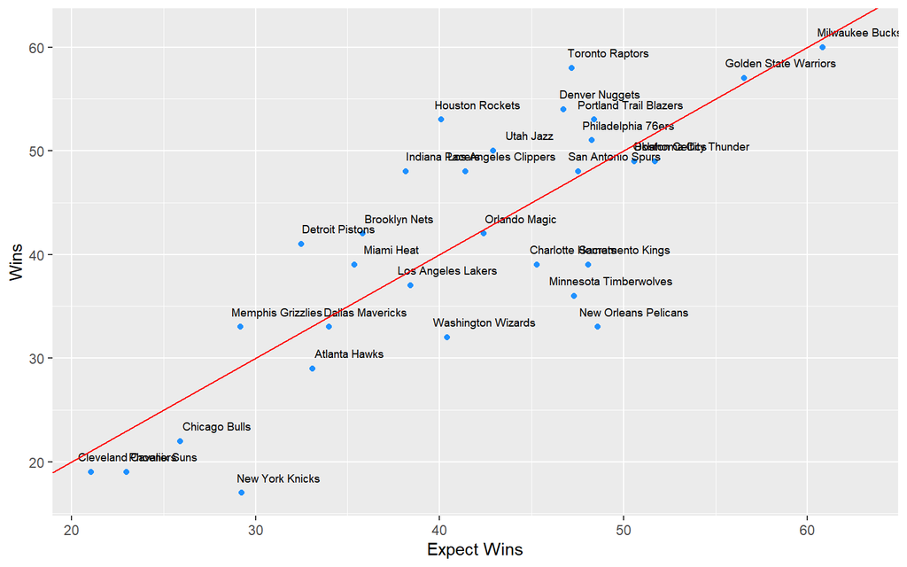

## Result

### Staring Player of Center

| player_name | Pos | salary | exp_t_wA |
| --- | --- | --- | --- |
| Anthony Davis | C | 25.434263 | 60.79847 |
| Joel Embiid | C | 25.467250 | 52.10191 |
| Andre Drummond | C | 25.434262 | 48.87446 |
| Nikola Vucevic | C | 12.750000 | 45.40050 |
| KarlAnthony Towns | C | 7.839435 | 45.18545 |
| Rudy Gobert | C | 23.491573 | 44.55648 |

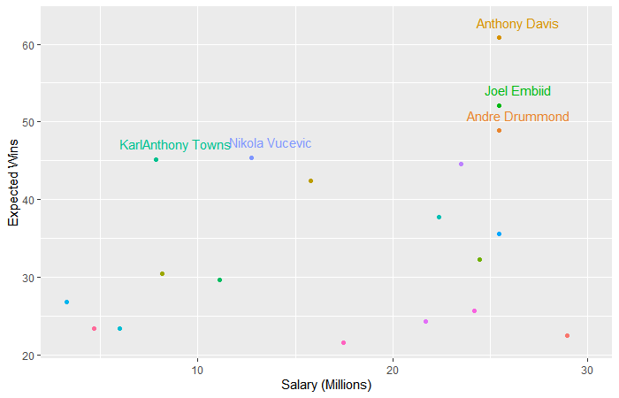

From the charts and figures, it can be found that the most skilled center is Anthony Davis, while his salary is also quite high.

By comparing the top 6 skilled centers, Karl Anthony Towns is the one with the highest price-performance ratio. We can put **KarlAnthony Towns** as the first choice.

### Staring Player of Power Forward

| player_name | Pos | salary | exp_t_wA |
| --- | --- | --- | --- |
| Giannis Antetokounmpo | PF | 24.157304 | 50.22390 |
| John Collins | PF | 2.299080 | 30.91401 |
| Lauri Markkanen | PF | 4.536120 | 30.07960 |
| Julius Randle | PF | 8.641000 | 26.54434 |
| Blake Griffin | PF | 31.873932 | 26.46324 |
| Pascal Siakam | PF | 1.544951 | 21.23898 |

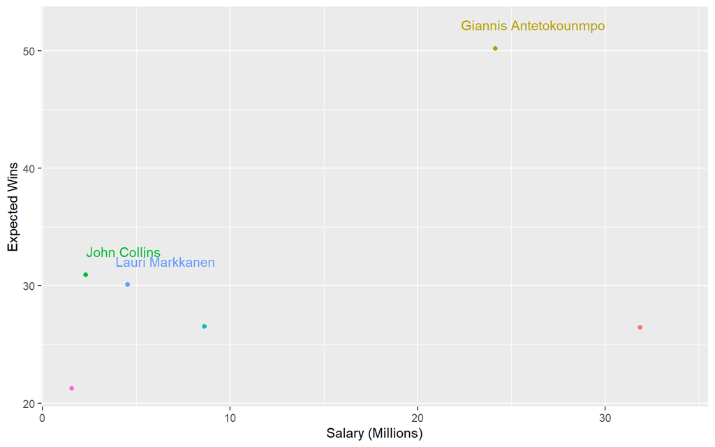

Giannis Antetokounmpo’s Adjusted Expected Wins Index is the highest in the power forward candidates,and is 60% higher than the second place (John Collins).

But our goal is *Ranked 26 out of 30*, so we do not need to choose a player with the highest ability. In addition, his salary is too high to our team.

Therefore, I recommend **John Collins** as our PF. He is good enough for our goal in 2019-2020 Season (26 out of 30), and his salary is also affordable for us.

### Staring Player of Small Forward

| player_name | Pos | salary | exp_t_wA |
| --- | --- | --- | --- |
| Paul George | SF | 30.56070 | 41.31393 |
| Kawhi Leonard | SF | 23.11407 | 39.25455 |
| LeBron James | SF | 35.65415 | 38.51224 |
| Kevin Durant | SF | 30.00000 | 33.16834 |
| Danilo Gallinari | SF | 21.58758 | 25.26936 |

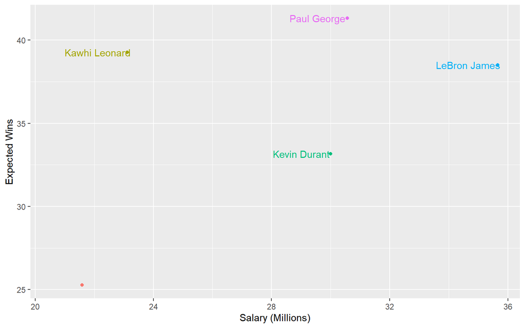

Kawhi Leonard’s expected wins index is only slightly lower than Paul George, but his salary is less than Paul almost 7 millions, so **Kawhi Leonard** is more valued and suit for us.

### Staring Player of Point Guard

| player_name | Pos | salary | exp_t_wA |
| --- | --- | --- | --- |
| James Harden | PG | 30.57000 | 38.55431 |
| Russell Westbrook | PG | 35.66500 | 35.80378 |
| Stephen Curry | PG | 37.45715 | 30.40308 |
| Damian Lillard | PG | 27.97769 | 29.06020 |
| Kyrie Irving | PG | 20.09919 | 28.57919 |
| Kemba Walker | PG | 12.00000 | 27.50688 |

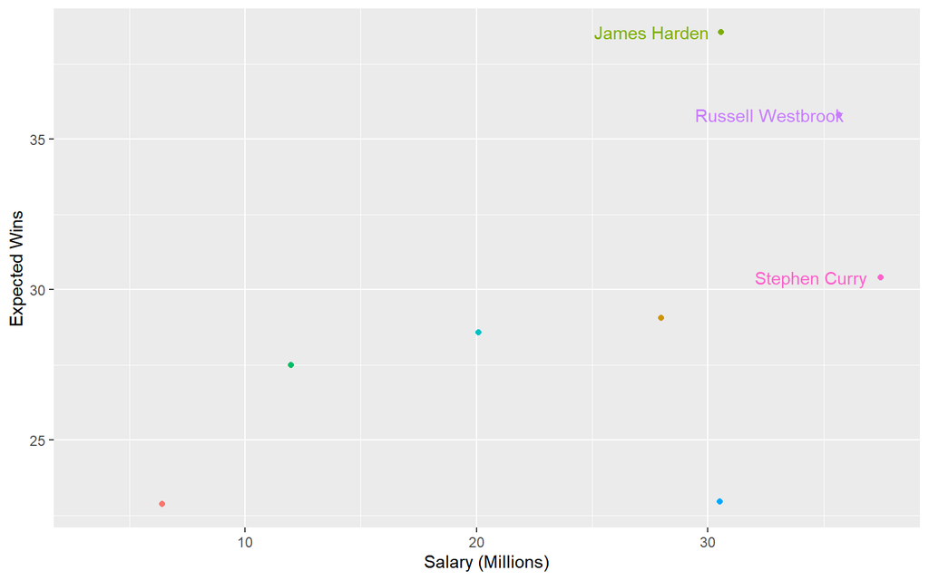

### Staring Player of Shooting Guard

| player_name | Pos | salary | exp_t_wA |
| --- | --- | --- | --- |
| Bradley Beal | SG | 25.43426 | 29.08058 |
| DeMar DeRozan | SG | 27.73998 | 24.87260 |
| Klay Thompson | SG | 18.98872 | 22.99806 |
| Luka Doncic | SG | 6.56904 | 22.58358 |
| Jrue Holiday | SG | 26.64111 | 22.24751 |
| CJ McCollum | SG | 25.75977 | 21.62918 |

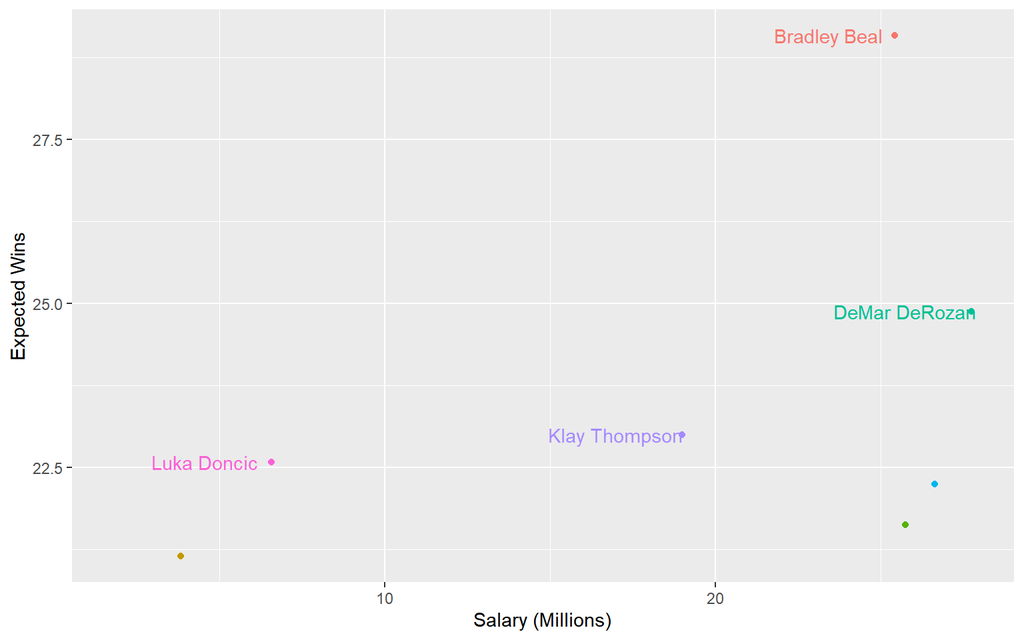

**Luka Doncic** is the best Shooting Guards for Chicago Bulls. His expected wins index is 22.6, but his salary is only 6.57 million.

## Summary & Recommendation

### Final Staring Players List

| player_name | Pos | salary | exp_t_wA |
| --- | --- | --- | --- |
| James Harden | PG | 30.570000 | 38.55431 |
| Kawhi Leonard | SF | 23.114066 | 39.25455 |
| KarlAnthony Towns | C | 7.839435 | 45.18545 |
| Luka Doncic | SG | 6.569040 | 22.58358 |
| John Collins | PF | 2.299080 | 30.91401 |

I recommend *James Harden(PG), Kawhi Leonard(SF), KarlAnthony Towns(C), Luka Doncic(SG), John Collins(PF)* these five players as Chicago Bulls’ staring players in the upcoming season.

*James Harden (PG)* has the highest salary among these five players, and he is well worth it.

A good point guard is essential for a team. They are regarded as leaders on the field [Wikipedia](https://en.wikipedia.org/wiki/Basketball_positions).

They can mobilize all players, implement tactics and provide assists, and they also can offense and score by themselves. In addition, a good point guard can facilitate other players to have clearer minds during the games. Therefore, it is worth to spent more money on this position.

[figure not shown]